# Week 8 assignment DNA Methylation Analysis

Iryna-ENElab

2026-05-05

Plot a heatmap of the methylation levels of the genes in top 5 DMR regions (from the practical) located on chr1. You may either do this as we did for promoters during the practical (i.e. using getMeth()), or using signal2Matrix() and plotEnrichedHeatmaps().

Use the differentially-methylated regions from the practical, and compare those changes to changes in accessibility. For the latter, you can download differential accessibility results from here: https://www.ethz-ins.org/content/ATAC_AstroVsESC_subset.rds Given these two datasets, figure out a way (visualization/analysis) of assessing the extent of agreement (or disagreement) between changes in these two modalities. Describe what you did and what it means in a sentence or two.

```r
suppressPackageStartupMessages({
  library(bsseq)
  library(DMRcate)
  library(GenomeInfoDb)
  library(GenomicRanges)
  library(ggplot2)
  library(pheatmap)
})
```

# Task 1: Heatmap of methylation levels at the top 5 DMR regions on chr1

## Load the data

Loading the DMR results produced during the practical (via `dmrcate()` and `extractRanges()`), as well as the BSseq object that contains per-CpG methylation data for the ESC and astrocyte samples.

```r
# DMR ranges saved at the end of the practical
dmrRanges <- readRDS("dmr.rds")

# BSseq object from the practical
bs <- readRDS("ESC_astrocytes_BSseq.rds")

# Remove CpGs with zero coverage in any sample (same filter as in the practical)
bs <- bs[rowSums(assay(bs, "Cov") > 0) == ncol(bs), ]
```

## Select the top 5 DMRs on chr1

I rank the DMRs by the absolute mean methylation difference so that we pick the regions with the largest effect sizes, then keep only those located on chromosome 1.

```r
# Keep only chr1 DMRs
dmrChr1 <- dmrRanges[seqnames(dmrRanges) == "chr1"]

# Order by absolute mean difference (largest changes first)
dmrChr1 <- dmrChr1[order(abs(dmrChr1$meandiff), decreasing = TRUE)]

# Take the top 5
top5 <- dmrChr1[1:min(5, length(dmrChr1))]
top5
```

```
## GRanges object with 5 ranges and 8 metadata columns:
##       seqnames              ranges strand |   no.cpgs min_smoothed_fdr
##          <Rle>           <IRanges>  <Rle> | <integer>        <numeric>
##   [1]     chr1 207818394-207818642      * |        19     2.24056e-271
##   [2]     chr1 240160779-240161545      * |        47      0.00000e+00
##   [3]     chr1 230993054-230993133      * |         6      1.82406e-77
##   [4]     chr1 207842898-207842965      * |         7      2.46074e-85
##   [5]     chr1   40598617-40598663      * |         5      1.35401e-59
##           Stouffer       HMFDR       Fisher   maxdiff  meandiff
##          <numeric>   <numeric>    <numeric> <numeric> <numeric>
##   [1] 2.50626e-186 1.87459e-12 2.35612e-178 -11.56201  -9.18854
##   [2]  0.00000e+00 3.04297e-12  0.00000e+00 -11.49759  -8.85801
##   [3]  8.49059e-57 7.03664e-11  2.53597e-54  -9.78203  -8.84035
##   [4]  8.08522e-63 3.82668e-11  3.25947e-60 -10.06336  -8.48854
##   [5]  3.61891e-45 6.03754e-11  4.27652e-43  -9.78331  -8.46054
##       overlapping.genes
##             <character>
##   [1]      CR1L, CD46P1
##   [2]              <NA>
##   [3]          C1orf198
##   [4]              CR1L
##   [5]      RP11-115D7.3
##   -------
##   seqinfo: 23 sequences from an unspecified genome; no seqlengths
```

## Extract per-region methylation and plot a heatmap

Following the practical, I use `bsseq::getMeth()` with `what = "perRegion"` to compute the average methylation ratio across all CpGs in each region, for every sample.

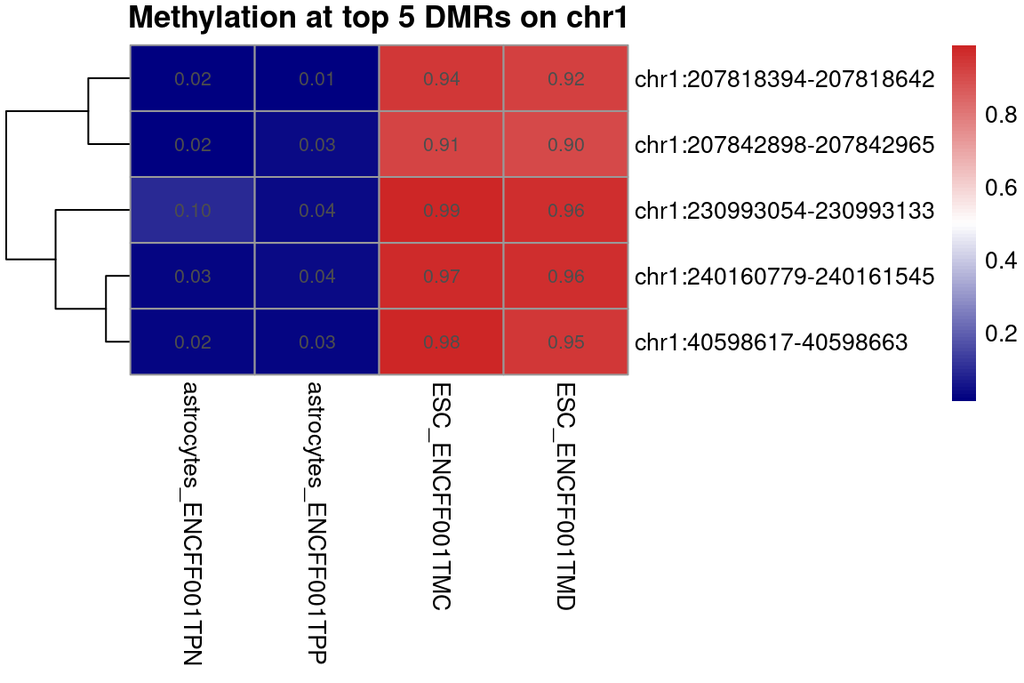

```r
# Extract average methylation per region per sample.
# Using type="raw" to compute ratios directly from the count data.
# For region-level averages across DMRs (many CpGs).
metTop5 <- bsseq::getMeth(bs, regions = top5, what = "perRegion", type = "raw")

# Label rows with genomic coordinates
rownames(metTop5) <- paste0(seqnames(top5), ":",
                            start(top5), "-", end(top5))
colnames(metTop5) <- colnames(bs)

# Plot a heatmap
pheatmap(metTop5,
         name            = "methylation",
         cluster_cols    = FALSE,
         main            = "Methylation at top 5 DMRs on chr1",
         color           = colorRampPalette(c("navy", "white", "firebrick3"))(100),
         display_numbers = TRUE,
         number_format   = "%.2f")
```

### Interpretation

The heatmap shows the average methylation ratio (0 = unmethylated, 1 = fully methylated) for each of the top 5 DMR regions on chromosome 1, across the ESC and astrocyte replicates.  
All 5 top DMR regions on Chr 1 show the pattern that methylation is low (2-10%) in astrocytes and very high (90-99%) in ESCs. This could mean that these regiobs undergo demethylation during the differentiation from ESCs to astrocytes whisch makes total sense due to biology of cell fate: during differentiation genomic regions lose DNA methylation to allow transcription factors to bind and activate specific gene programs

# Task 2: Comparing DMR changes to changes in chromatin accessibility

## Load the differential accessibility data

The differential accessibility results were generated from ATAC-seq data comparing the same cell types (astrocytes vs. ESC).

```r
options(timeout = 6000)
# Download the ATAC differential accessibility results
download.file(
  "https://www.ethz-ins.org/content/ATAC_AstroVsESC_subset.rds",
  "ATAC_AstroVsESC_subset.rds"
)
atacRes <- readRDS("ATAC_AstroVsESC_subset.rds")
head(atacRes)
```

```
## GRanges object with 6 ranges and 4 metadata columns:
##       seqnames              ranges strand |     logFC    logCPM       PValue
##          <Rle>           <IRanges>  <Rle> | <numeric> <numeric>    <numeric>
##   [1]     chr3   32911212-32911472      * | -14.53804   2.57720 1.84223e-185
##   [2]     chr8     9007982-9008485      * | -13.66711   1.65566 6.70803e-143
##   [3]     chr3   57164721-57165102      * | -15.00431   3.05803 6.19768e-137
##   [4]    chr22   46476146-46476721      * |  14.11141   1.44761 5.26376e-134
##   [5]     chr1   23763045-23763443      * | -14.54371   2.58018 1.99867e-133
##   [6]    chr12 124907086-124908139      * |   8.93254   1.68093 4.15580e-133
##                FDR
##          <numeric>
##   [1] 1.22824e-180
##   [2] 4.25568e-139
##   [3] 3.09624e-133
##   [4] 2.32832e-130
##   [5] 8.57188e-130
##   [6] 1.75564e-129
##   -------
##   seqinfo: 24 sequences from an unspecified genome; no seqlengths
```

## Strategy

I am assessing whether regions that gain or lose DNA methylation in astrocytes compared to ESCs also tend to lose or gain chromatin accessibility. I expect an inverse relationship: DNA methylation is associated with a repressive chromatin state so the regions becoming more methylated should tend to become less accessible and vice-versa.

To quantify this

1. Overlap the DMRs with the differential accessibility regions using `findOverlaps()`.
2. For each overlapping pair, retrieve the methylation change (`meandiff` from DMRcate) and the accessibility change (log-fold-change from the ATAC-seq analysis).
3. Visualise the relationship with a scatter plot and compute a correlation.

## Find overlaps between DMRs and ATAC regions

```r
# Make sure both objects use the same seqlevel style
seqlevelsStyle(dmrRanges) <- "UCSC"

# If atacRes is a data.frame/DFrame, convert to GRanges;
# if it is already a GRanges, this step adjusts style only.
if (is(atacRes, "GRanges")) {
  seqlevelsStyle(atacRes) <- "UCSC"
  atacGR <- atacRes
} else {
  # Typical edgeR/DESeq2 output stored as a data.frame with chr, start, end columns
  atacGR <- makeGRangesFromDataFrame(atacRes, keep.extra.columns = TRUE)
  seqlevelsStyle(atacGR) <- "UCSC"
}

# Find overlaps
hits <- findOverlaps(dmrRanges, atacGR)
hits
```

```
## Hits object with 5279 hits and 0 metadata columns:
##          queryHits subjectHits
##          <integer>   <integer>
##      [1]         1        1505
##      [2]         1        2041
##      [3]         1        2860
##      [4]         1        2983
##      [5]         1        3176
##      ...       ...         ...
##   [5275]      2576        3187
##   [5276]      2577        1286
##   [5277]      2578        5252
##   [5278]      2579        2879
##   [5279]      2580        1205
##   -------
##   queryLength: 2580 / subjectLength: 5279
```

## Build a combined table and visualise

```r
# Extract the methylation change from DMRs
methDiff <- dmrRanges$meandiff[queryHits(hits)]

# Extract the accessibility change — the column name depends on the
# analysis tool used; common names are logFC, log2FoldChange, or Diff.
# We inspect the metadata columns to pick the right one:
atacMcols <- mcols(atacGR)
cat("ATAC metadata columns:", paste(colnames(atacMcols), collapse = ", "), "\n")
```

```
## ATAC metadata columns: logFC, logCPM, PValue, FDR
```

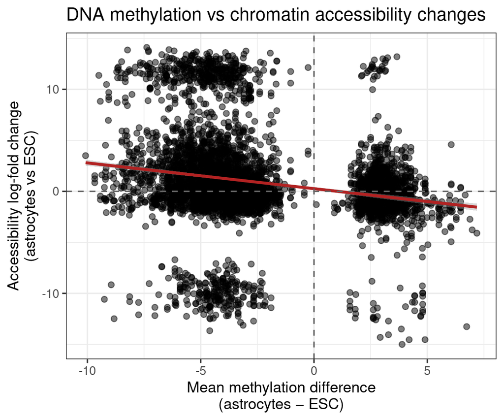

```r
# Attempt to use the most likely column name
if ("logFC" %in% colnames(atacMcols)) {
  atacLFC <- atacMcols$logFC[subjectHits(hits)]
} else if ("log2FoldChange" %in% colnames(atacMcols)) {
  atacLFC <- atacMcols$log2FoldChange[subjectHits(hits)]
} else {
  # Fallback: use the first numeric column as a proxy
  numCols <- sapply(atacMcols, is.numeric)
  atacLFC <- atacMcols[[which(numCols)[1]]][subjectHits(hits)]
}

# Combine into a data frame for plotting
df <- data.frame(
  meth_change = methDiff,
  atac_change = atacLFC
)

# Scatter plot
ggplot(df, aes(x = meth_change, y = atac_change)) +
  geom_point(alpha = 0.5, size = 2) +
  geom_smooth(method = "lm", se = TRUE, colour = "firebrick") +
  geom_hline(yintercept = 0, linetype = "dashed", colour = "grey40") +
  geom_vline(xintercept = 0, linetype = "dashed", colour = "grey40") +
  labs(
    x = "Mean methylation difference\n(astrocytes − ESC)",
    y = "Accessibility log-fold change\n(astrocytes vs ESC)",
    title = "DNA methylation vs chromatin accessibility changes"
  ) +
  theme_bw(base_size = 13)
```

```r
# Pearson correlation
cor_test <- cor.test(df$meth_change, df$atac_change, method = "pearson")
cor_test
```

```
##
##  Pearson's product-moment correlation
##
## data:  df$meth_change and df$atac_change
## t = -14.645, df = 5277, p-value < 2.2e-16
## alternative hypothesis: true correlation is not equal to 0
## 95 percent confidence interval:
##  -0.2234086 -0.1715607
## sample estimates:
##        cor
## -0.1976229
```

To give a simpler summary, classify each overlapping region as concordant (methylation up / accessibility down, or methylation down / accessibility up) or discordant, and show the proportions

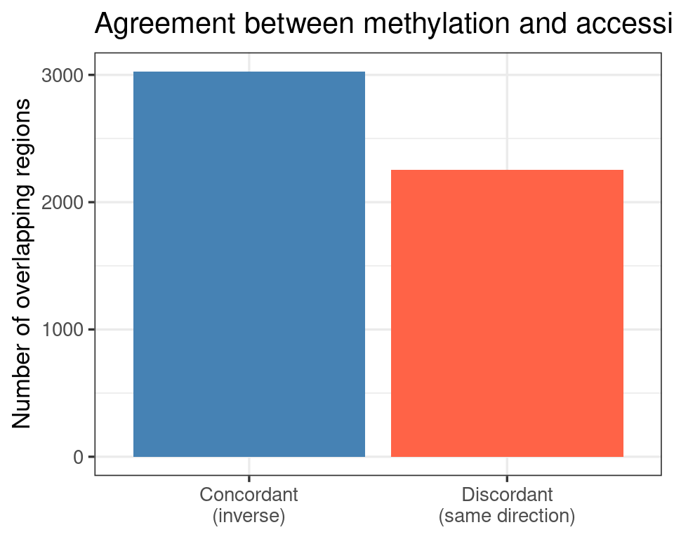

```r
df$direction <- ifelse(
  (df$meth_change > 0 & df$atac_change < 0) |
  (df$meth_change < 0 & df$atac_change > 0),
  "Concordant\n(inverse)",
  "Discordant\n(same direction)"
)

ggplot(df, aes(x = direction, fill = direction)) +
  geom_bar() +
  scale_fill_manual(values = c("steelblue", "tomato")) +
  labs(
    x = NULL, y = "Number of overlapping regions",
    title = "Agreement between methylation and accessibility changes"
  ) +
  theme_bw(base_size = 13) +
  theme(legend.position = "none")
```

## Interpretation

I overlapped the differentially-methylated regions (DMRs) identified by DMRcate with the differential accessibility results from ATAC-seq (astrocytes vs. ESC) using `findOverlaps()`, then compared mathylation change with (meandiff), with the accessibility log-fold change for each overlapping region. The analysis reveals a negative correlation between methylation change and accessibility change: regions that gain methylation in astrocytes tend to lose accessibility, and vice-versa. The bar chart confirms this quantitatively (roughly 58%) of overlapping regions show concordant (inverse) changes(about 42%) change in the same direction (discordant). This is consistent with repressive role of DNA methylation, which inhibits transcription factor binding and is associated with closed chromatin states.